# Spatial Statistics in Epidemiology and Public Health - SISMID 2026

July 17, 2026

# 1 Working with Spatial Point Pattern

We will first load in the Atlanta police department crime data from 2014 and its jurisdiction shapefile. These files were obtained from [here](http://www.atlantapd.org/crimedatadownloads.aspx). The ATL police department is divided into 6 zones [map](http://www.atlantapd.org/findmyzone.aspx), plus the airport. We will drop the airport in this analysis.

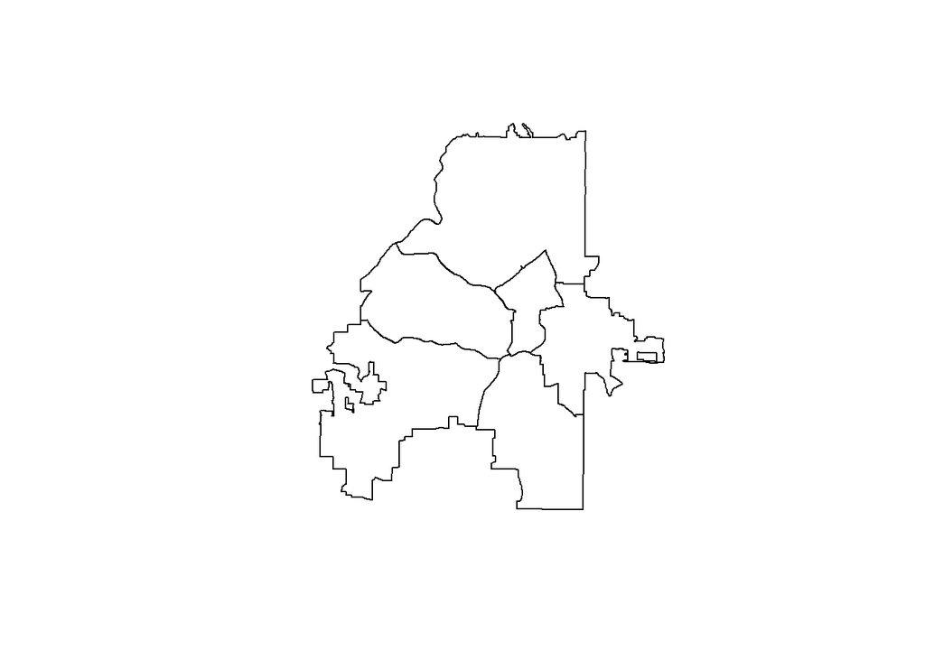

```r
library (sf)
library (ggplot2)
library (here)
dat = st_read("apd_NewZone_2011_region.shp")
#Remove airport
dat = dat[-1,]
plot (st_geometry(dat))
```

Next we will load a CSV file containing occurrences of crime. The data set has the following variables.

```r
crime = read.csv ("ATL_Crime_2014.csv")
summary (crime)
```

```
##   occur_date         occur_time            Type                 x
##  Length:31149       Length:31149       Length:31149       Min.   :-84.55
##  Class :character   Class :character   Class :character   1st Qu.:-84.44
##  Mode  :character   Mode  :character   Mode  :character   Median :-84.40
##                                                           Mean   :-84.41
##                                                           3rd Qu.:-84.37
##                                                           Max.   : 14.00
##        y               hour
##  Min.   :-84.38   Min.   : 0.00
##  1st Qu.: 33.73   1st Qu.: 9.00
##  Median : 33.75   Median :14.00
##  Mean   : 33.75   Mean   :13.35
##  3rd Qu.: 33.78   3rd Qu.:19.00
##  Max.   : 33.88   Max.   :23.00
```

We will need to do several things in preparation for a point pattern analysis.

1. Fuse the 6 polygons into an overall study region.
2. Make sure all points fall within the study region.
3. Perform projection to use Euclidean distance in subsequent analyses.

```r
## Fuse polygons
region = st_union (dat)

## Check overlap
crime = st_as_sf(crime, coords = c("x","y"))
st_crs (crime) = st_crs (region)
check.overlap = as.matrix(st_contains ( region, crime))
crime = crime[check.overlap, ]
```

Here is a map of the joined regions and all the reported crime events.

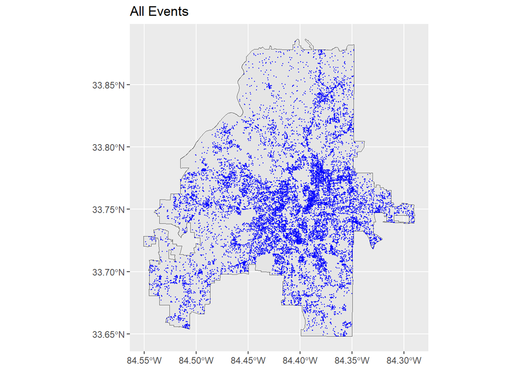

```r
ggplot() + geom_sf (data=st_geometry(region)) + geom_sf (data=st_geometry (crime), col = "blue", size = 0.2) +
  labs (title="All Events")
```

We need to have the longitude and latitude projected for later analyses.

```r
## Projection to the USA Contiguous Albers Equal Area
crs.albers = "+proj=aea +lat_1=29.5 +lat_2=45.5 +lat_0=37.5 +lon_0=-96 +x_0=0 +y_0=0 +ellps=GRS80 +datum=NAD83 +units=m +no_defs"
crime = st_transform(crime, crs.albers)
region = st_transform (region, crs.albers )
```

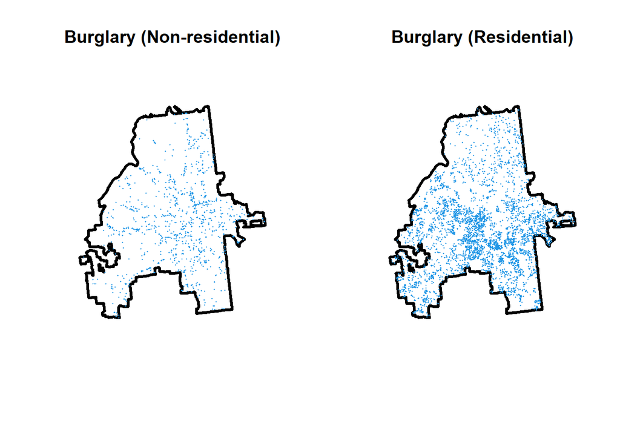

```r
#Some Exploratory Plots
par (mfrow = c(1,2))
plot (region, lwd=3, main = "Burglary (Non-residential)")
lines (st_coordinates(crime)[crime$Type =="BURGLARY-NONRES",], col = 4, pch = 16, type = "p", cex = 0.2)
plot (region, lwd=3, main = "Burglary (Residential)")
lines (st_coordinates(crime)[crime$Type =="BURGLARY-RESIDENCE",], col = 4, pch = 16, type = "p", cex = 0.2)
```

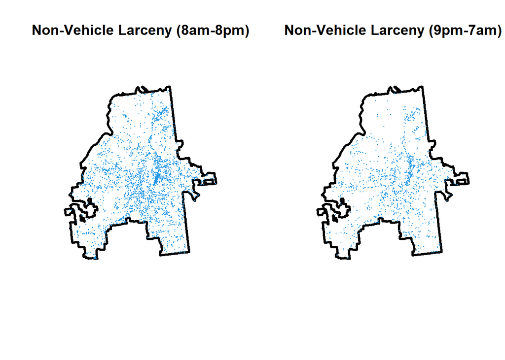

```r
par (mfrow = c(1,2))
plot (region, lwd=3, main = "Non-Vehicle Larceny (8am-8pm)")
lines (st_coordinates(crime)[crime$Type =="LARCENY-NON VEHICLE"& crime$hour %in% c(8:20),], col = 4, pch = 16, type = "p", cex = 0.2)
plot (region, lwd=3, main = "Non-Vehicle Larceny (9pm-7am)")
lines (st_coordinates(crime)[crime$Type =="LARCENY-NON VEHICLE"& !crime$hour %in% c(8:20),], col = 4, pch = 16, type = "p", cex = 0.2)
```

# 2 Point Pattern Analysis

The package *spatstat* contains the majority of functions to do point pattern analysis. To store point pattern data *spatstat* uses the object *ppp*. Some important components of *ppp* are:

1. x: Vector of x coordinates of points.
2. y: Vector of y coordinates of points.
3. window: define the study region. This is not the same as a *SpatialPolygon* object.
4. marks: values associated with the points

Here we use burglary at residence as an example. Feel free to choose any other type of crime to analyze!

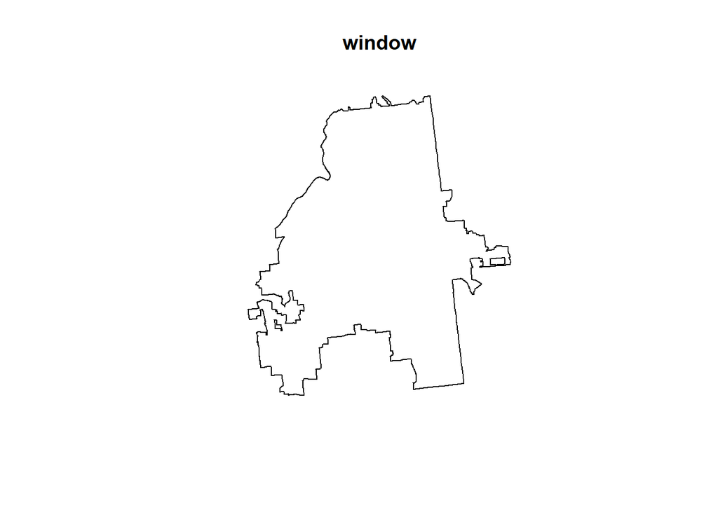

```r
library (spatstat)

#Convert the sf to "window" for spatstat
window = as.owin (region)
plot (window)
```

```r
summary (window)
```

```
## Window: polygonal boundary
## 2 separate polygons (1 hole)
##                  vertices      area relative.area
## polygon 1            4157 345915000      1.000000
## polygon 2 (hole)       43   -294739     -0.000853
## enclosing rectangle: [1050927.9, 1074594.2] x [-366532.5, -339467.2] units
##                      (23670 x 27070 units)
## Window area = 345621000 square units
## Fraction of frame area: 0.54
```

```r
points = st_coordinates(crime)[ crime$Type == "BURGLARY-RESIDENCE",]
pp = ppp (x=points[,1], y = points[,2], window = window)

#Rescale to km and add the unit information
pp = rescale (pp, s = 1000)
unitname(pp) <- "km"

summary (pp)
```

```
## Planar point pattern:  5946 points
## Average intensity 17.20383 points per square km
##
## *Pattern contains duplicated points*
##
## Coordinates are given to 13 decimal places
##
## Window: polygonal boundary
## 2 separate polygons (1 hole)
##                  vertices       area relative.area
## polygon 1            4157 345.915000      1.000000
## polygon 2 (hole)       43  -0.294739     -0.000853
## enclosing rectangle: [1050.9279, 1074.5942] x [-366.5325, -339.4672] km
##                      (23.67 x 27.07 km)
## Window area = 345.621 square km
## Unit of length: 1 km
## Fraction of frame area: 0.54
```

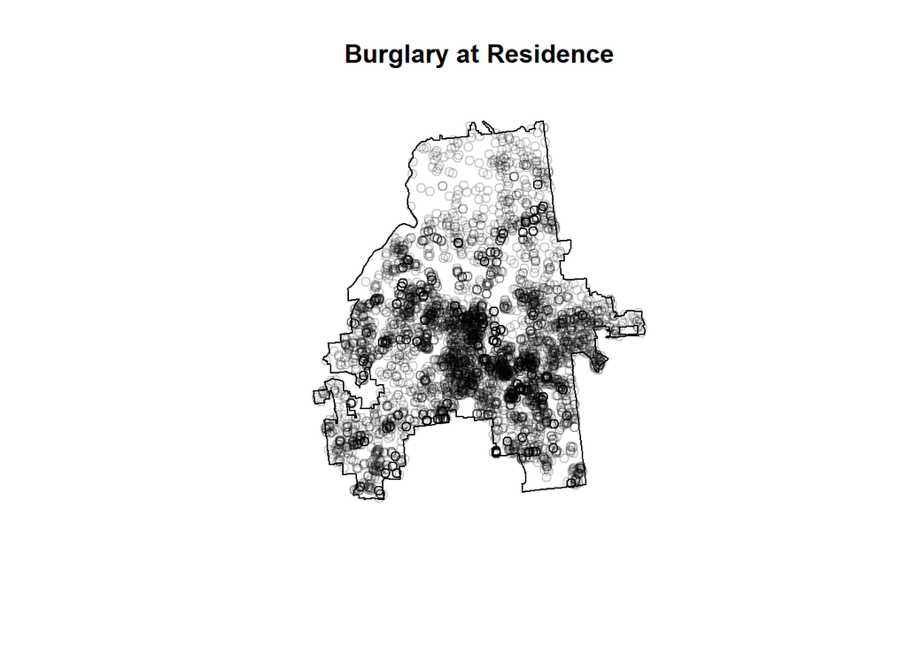

```r
plot (pp, main = "Burglary at Residence")
```

# 3 Exploratory Analysis: Intensity

The *density* function provides estimated intensity. We will need to select a bandwidth (sigma). The figures below compare sigma = 0.5, 1 or 2.

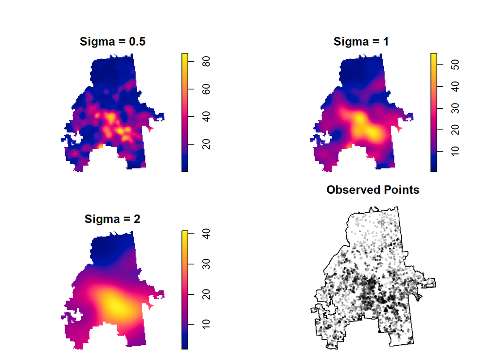

```r
#First examine different Gaussian kernel bandwidth (standard deviation = sigma)
par (mfrow = c(2,2), mar = c(0,0,2,0))
plot (density(pp, sigma=0.5), main = "Sigma = 0.5")
plot (density(pp, sigma=1), main = "Sigma = 1")
plot (density(pp, sigma=2), main = "Sigma = 2")
plot (pp, cex=0.4, pch = 16, main = "Observed Points")
```

We often apply an “edge-correction” to the intensity map because the kernel window will include regions outside of the study area near the boundary. Below we choose bandwidth sigma = 1, and apply two common correction methods.

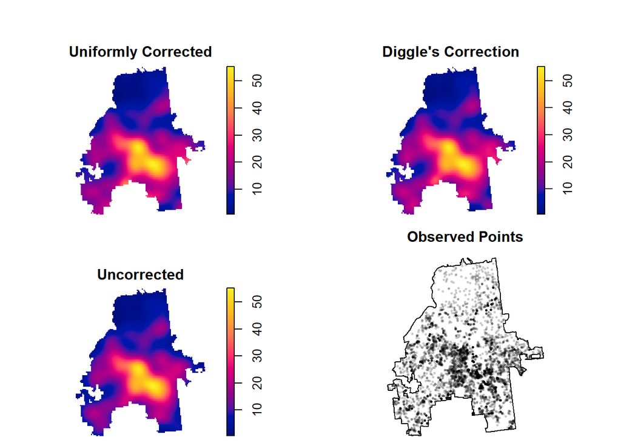

```r
par (mfrow = c(2,2), mar = c(0,0,2,0))
plot (density(pp, sigma=1), main = "Uniformly Corrected") ##Uniform corrected
plot (density(pp, sigma=1, diggle=TRUE), main = "Diggle's Correction") #Diggle corrected
plot (density(pp, sigma=1, edge = FALSE), main = "Uncorrected") #Uncorrected
plot (pp, cex=0.4, pch = 16, main = "Observed Points")
```

# 4 Relative Ratio of Two Intensity Functions

Point patterns often have “marked” attributes and we may be interested in how different intensities vary spatially. Here we will estimate relative rate of residential robbery versus residential burglary using the R package *sparr*

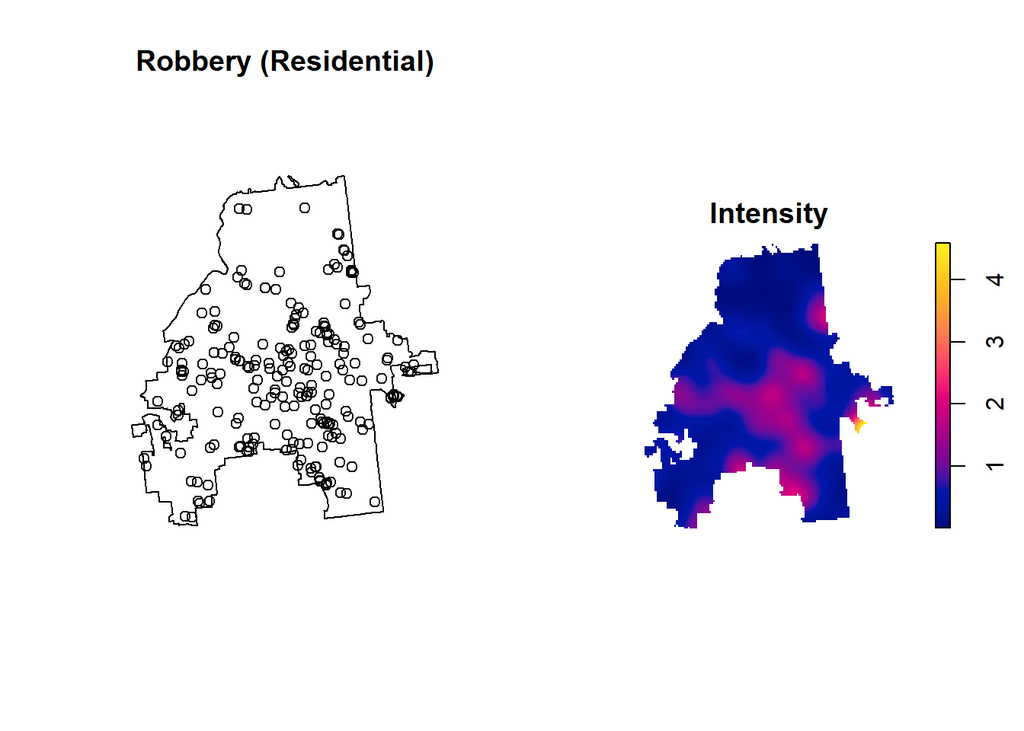

```r
points = st_coordinates(crime)[ crime$Type == "ROBBERY-RESIDENCE",]
pp_rob = ppp (x=points[,1], y = points[,2], window = window)
pp_rob = rescale (pp_rob, s = 1000)

par (mfrow = c(1,2))
plot (pp_rob, main = "Robbery (Residential)")
plot (density(pp_rob, cex = 0.4, sigma=1, edge = TRUE), main = "Intensity")
```

Here is the ratio of intensities (robbery versus burglary).

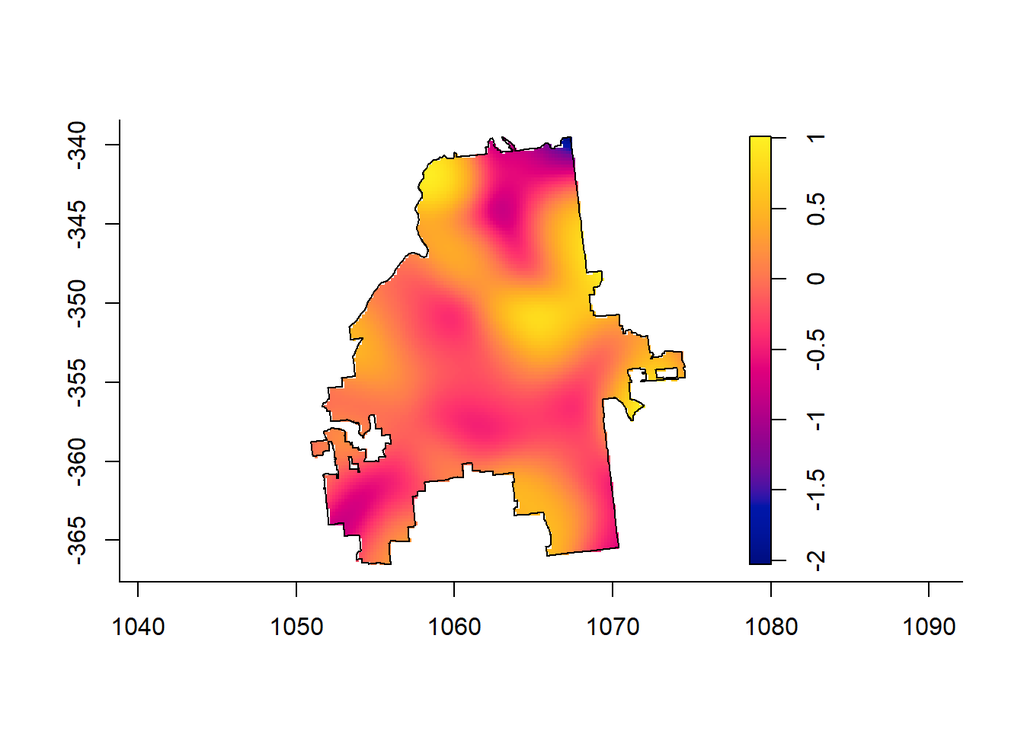

```r
library (sparr)
fit = risk (pp_rob, pp, edge="diggle")
plot (fit, mian = "Log Ratio")
```

# 5 Spatial Dependence and K-function

Next we will examine spatial dependence cumulative distribution of the average number of points within a specific radius. We will compare residential burglary and vehicle larceny.

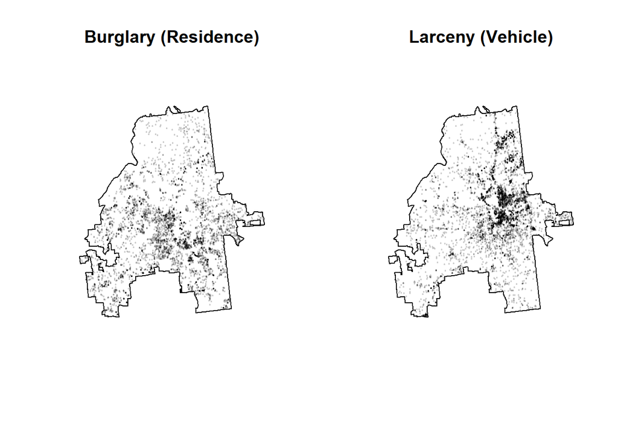

```r
points1 = st_coordinates(crime)[crime$Type == "BURGLARY-RESIDENCE",]
pp1 = ppp (x=points1[,1], y = points1[,2], window = window)

points2 = st_coordinates(crime)[crime$Type == "LARCENY-FROM VEHICLE",]
pp2 = ppp (x=points2[,1], y = points2[,2], window = window)

par (mfrow = c(1,2))
plot (pp1, main = "Burglary (Residence)", cex = 0.2)
plot (pp2, main = "Larceny (Vehicle)", cex = 0.2)
```

Below are the k-functions estimated with edge-correction (“border”) or uncorrected (“un”). The green line (“pois”) represents the k-function under homogeneity (i.e., $\pi r^2$). We can see evidence of stronger dependence for vehicle larceny compared to burglary.

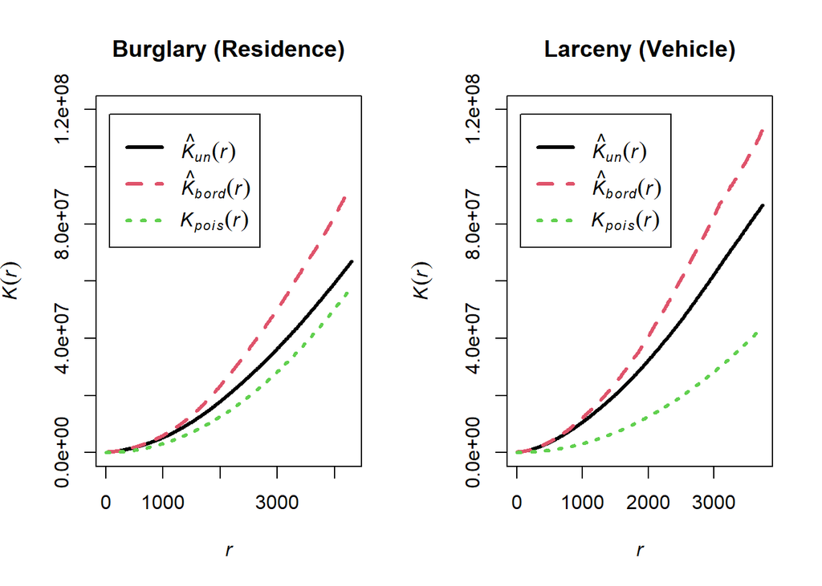

```r
par (mfrow = c(1,2))
plot (Kest (pp1, correction = c("none", "border")), main = "Burglary (Residence)", lwd = 3, ylim = c(0, 1.2e+08))
plot (Kest (pp2, correction = c("none", "border")), main = "Larceny (Vehicle)", lwd = 3, ylim = c(0, 1.2e+08))
```